# FML Assignment 4

Ajith Raj Periyasamy

2024-03-17

### Summary

The analysis of 21 firms using K-Means, DBSCAN, and Hierarchical Clustering techniques identified clear clusters based on numerical variables. K-Means with k=5 was deemed optimal, showcasing distinct differences in market capitalization, volatility, profitability, and leverage among clusters. Additionally, non-clustering variables revealed patterns in revenue growth and net profit margin. The clusters were named “Balancing Act: Growth, Risk and Opportunity” and “Stable Profits: Market Leaders” to reflect their unique characteristics and paves way for future research.

```r
# First step is to load the necessary packages:
library(tidyverse)
library(factoextra)
library(fpc)
library(dbscan)
```

```r
library(stats)
library(ggplot2)
library(dendextend)
library(cluster)
```

```r
# setting up wd:
setwd("/Users/ajithrajperiyasamy/Desktop/FILES/KSU FILES/ASSIGNMENTS/FML/Clustering")
```

```r
# Importing the dataset:
data <- read.csv("/Users/ajithrajperiyasamy/Desktop/FILES/KSU FILES/ASSIGNMENTS/FML/Clustering/Pharmaceuticals.csv")
data <- na.omit(data)
head(data,2)
```

```
##   Symbol                Name Market_Cap Beta PE_Ratio  ROE  ROA Asset_Turnover
## 1    ABT Abbott Laboratories      68.44 0.32     24.7 26.4 11.8            0.7
## 2    AGN      Allergan, Inc.       7.58 0.41     82.5 12.9  5.5            0.9
##   Leverage Rev_Growth Net_Profit_Margin Median_Recommendation Location Exchange
## 1     0.42       7.54              16.1          Moderate Buy       US     NYSE
## 2     0.60       9.16               5.5          Moderate Buy   CANADA     NYSE
```

```r
tail(data,2)
```

```
##    Symbol                         Name Market_Cap Beta PE_Ratio  ROE  ROA
## 20    WPI Watson Pharmaceuticals, Inc.       3.26 0.24     18.4 10.2  6.8
## 21    WYE                        Wyeth      48.19 0.63     13.1 54.9 13.4
##    Asset_Turnover Leverage Rev_Growth Net_Profit_Margin Median_Recommendation
## 20            0.5     0.20      29.18              15.1         Moderate Sell
## 21            0.6     1.12       0.36              25.5                  Hold
##    Location Exchange
## 20       US     NYSE
## 21       US     NYSE
```

```r
colnames(data) #Using colnames to identify the names of columns and view how many are present.
```

```
##  [1] "Symbol"                "Name"                  "Market_Cap"
##  [4] "Beta"                  "PE_Ratio"              "ROE"
##  [7] "ROA"                   "Asset_Turnover"        "Leverage"
## [10] "Rev_Growth"            "Net_Profit_Margin"     "Median_Recommendation"
## [13] "Location"              "Exchange"
```

Clustering 21 firms using numeric variables ranging from 1 to 9.

```r
row.names(data) <- data[,1]
cluster <- data[,3:11]
```

Data Scaling

```r
set.seed(19)
Scaled_data<-scale(cluster)
```

Kmeans for random K values

```r
set.seed(19)
k_data_2<-kmeans(Scaled_data,centers = 2, nstart = 15)
k_data_4<-kmeans(Scaled_data,centers = 4, nstart = 15)
k_data_8<-kmeans(Scaled_data,centers = 8, nstart = 15)
plot_k_data_2<-fviz_cluster(k_data_2,data = Scaled_data) + ggtitle("K Means = 2") + theme_minimal()
plot_k_data_4<-fviz_cluster(k_data_4,data = Scaled_data) + ggtitle("K Means = 4") + theme_minimal()
plot_k_data_8<-fviz_cluster(k_data_8,data = Scaled_data) + ggtitle("K Means = 8") + theme_minimal()
```

Graphical Display of K Values: 2, 4, and 8

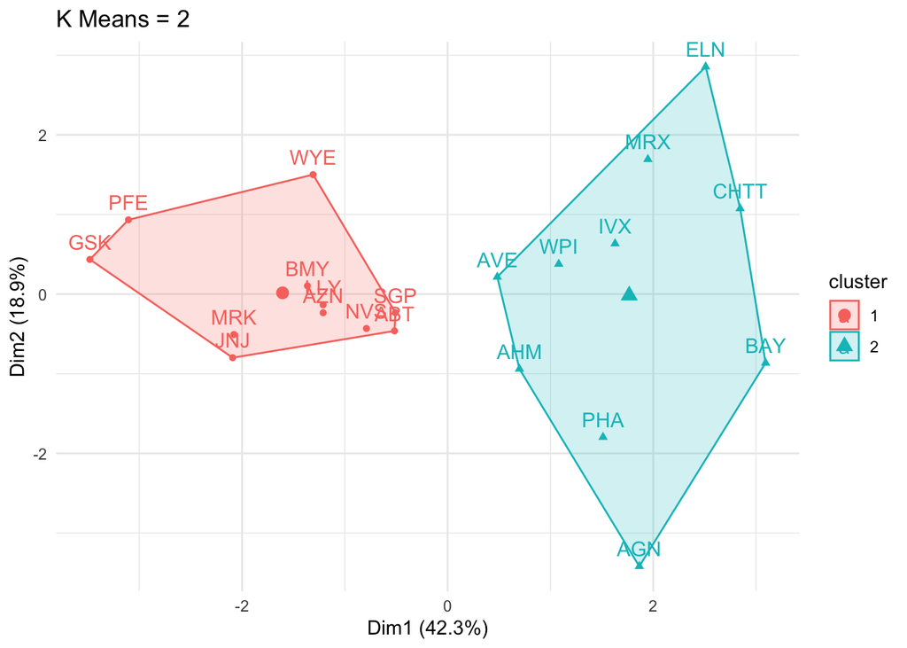

```r
plot_k_data_2
```

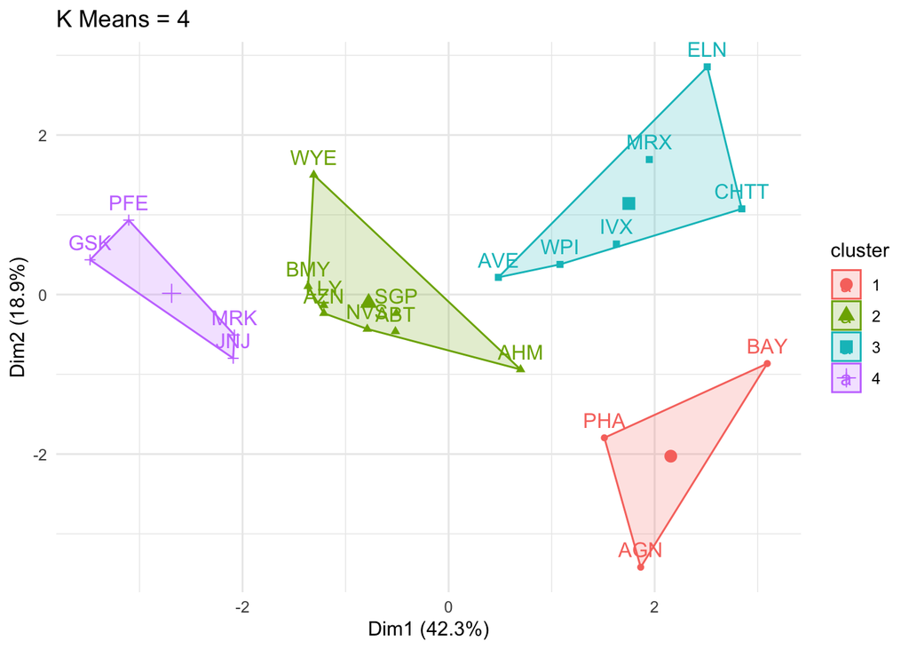

```r
plot_k_data_4
```